# Chocolate

```r
View(choc)
```

**Comments to Critiquers:**

## Background

I have been to several countries such as China, Turkey, Greece, USA, Canada, and South Korea. In this data, location means where chocolate factory located at. I am curious which country chocolate has higher rating. I decided to run the test with only three countries: Canada, South Korea, and USA.

$$H_0: \text{ All samples are from the same distribution.}$$
$$H_a: \text{At least one sample's distribution is stochastically different}$$

Note : Rating 5 = Elite, 4 = Premium, 3 =Satisfactory to praiseworthy, 2 = Disappointing, 1 = Unpleasant.

## Analysis

Kruskal-Wallis shows p-values is smaller than significant level and have sufficient evidence to reject the null hypothesis. In other words, at least one sample’s distribution is stochastically different. We don’t know which one it is just with Krusal-Wallis test. Boxplot can help with this problem.

```r
pander(favstats(Rating ~ Location, data=chocolate))
```

| Location | min | Q1 | median | Q3 | max | mean | sd | n | missing |
| --- | --- | --- | --- | --- | --- | --- | --- | --- | --- |
| Canada | 2 | 3 | 3.25 | 3.75 | 4 | 3.319 | 0.4209 | 124 | 0 |
| South Korea | 2.75 | 3.25 | 3.25 | 3.25 | 3.5 | 3.2 | 0.2739 | 5 | 0 |
| U.S.A. | 1.5 | 2.75 | 3.25 | 3.5 | 4 | 3.154 | 0.442 | 764 | 0 |

```r
pander(kruskal.test(Rating ~ as.factor(Location), data=chocolate))
```

Kruskal-Wallis rank sum test: `Rating` by `as.factor(Location)`

| Test statistic | df | P value |
| --- | --- | --- |
| 14.94 | 2 | 0.0005701 * * * |

Boxplots show that in the sample, Canada and USA chocolate boxplot looks pretty similar but we can tell that Canada quartile is slightly higher than USA.

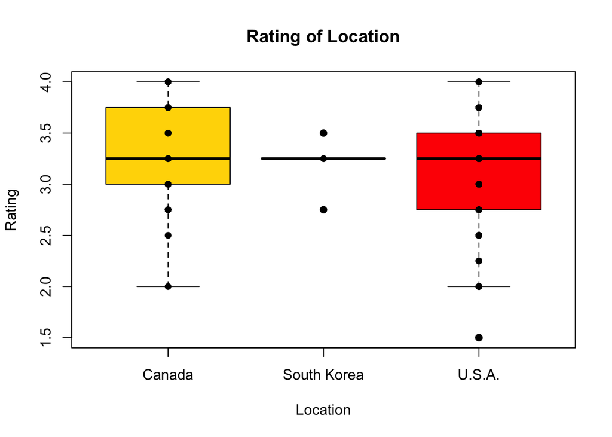

```r
boxplot( Rating ~ Location, data=chocolate, col =(c("gold","darkgreen","red")), xlab="Location", ylab="Rating", main="Rating of Location")
stripchart(Rating ~ Location, data=chocolate, vertical =TRUE, pch=16, add=TRUE, col="black")
```

```r
pander(wilcox.test(Rating ~ Location, data=subset(chocolate, Location != "South Korea")))
```

Wilcoxon rank sum test with continuity correction: `Rating` by `Location`

| Test statistic | P value | Alternative hypothesis |
| --- | --- | --- |
| 57448 | 0.0001136 * * * | two.sided |